# Майнор "Интеллектуальный анализ данных"

# Курс "Современные методы машинного обучения"

# Лабораторная работа №1. Image Classification.

В данной лабораторной работе вам предлагается обучить модель на основе нейронной сети для распознавания рукописных букв английского алфавита.

## Данные

Данные представлены двумя датасетами: обучающим (`train`) и тестовым (`test`). Изображения для каждого датасета находятся в `images.zip`.

Обучающая выборка состоит из 65000 изображений - по 2500 изображений для каждой буквы.  
Тестовая выборка состоит из 13000 изображений - по 500 изображений для каждой буквы.

Все изображения - монохромные (но в формате RGB), размерности $28 \times 28$ пикселей, в формате JPEG. В названии каждого файла содержатся буква, которая представлена на изображении, и уникальный номер изображения: `a_00002.jpg`.

**NB:** Все изображения представлены в перевернутом виде, для корректного отображения их нужно сначала транспонировать.

```python
import numpy as np
import matplotlib.pyplot as plt
```

```python
pic = plt.imread('images/train/a/a_00002.jpg')
print(pic.shape)
```

```
(28, 28, 3)
```

```python
pic = np.transpose(pic, axes=(1, 0, 2))
```

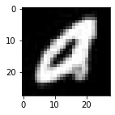

```python
plt.figure(figsize=(2,2))
plt.imshow(pic)
plt.show()
```

## Основные задания

Ваша задача - создать и обучить модель на основе нейронной сети, которая будет предсказывать букву на картинке.  
Обучение необходимо проводить на данных из `train`, качество модели проверять на данных из `test`.  
Целевая метрика - accuracy.  
Для моделирования необходимо использовать `pytorch`.

### Задание 1

*Вес в общей оценке - 0.35*

1. Постройте и обучите модели с 2-мя и 3-мя полносвязными (dense) скрытыми слоями.  
   При моделировании необходимо попробовать разные параметры нейронной сети - число нейронов на каждом слое, learning rate, batch size, функции активации, регуляризации и т.д. Оцените качество моделей с различными параметрами, проведите сравнительный анализ.
2. Для наилучшей модели постройте confusion matrix результатов предсказаний модели на тестовых данных.  
   Насколько равномерно обучилась ваша модель? Приведите буквы с самой лучшей и с самой худшей точностью детекции.
3. Найдите 10 пар букв, которые чаще всего путаются между собой, дайте возможное объяснение. Приведите примеры с картинками, которые были детектированы с ошибкой.
4. Возьмите первую букву вашей фамилии и укажите её точность детекции. С какими буквами ваша модель чаще всего путает эту букву?

```python
from google.colab import drive
drive.mount('/content/drive')
import torch
import torchvision.transforms as tfs
import torchvision
from torchvision import datasets, models , transforms
from torch.utils.data import DataLoader, Dataset
import numpy as np
from torch.nn.functional import cross_entropy
import torch.nn as nn
from torchsummary import summary
import matplotlib.pyplot as plt
from sklearn.metrics import accuracy_score
import sklearn.metrics as metrics
from tqdm import tqdm_notebook
import pandas as pd
import zipfile
```

```python
from google.colab import drive
drive.mount('/content/drive')
```

```python
zip_file = '/content/drive/MyDrive/images.zip'

data = zipfile.ZipFile(zip_file, 'r')
data.extractall()

data_tfs = tfs.Compose([
    transforms.ToTensor(),
    transforms.Normalize([0.485, 0.456, 0.406], [0.229, 0.224, 0.225]),
    transforms.Grayscale(1)
    ])

train_dataset = torchvision.datasets.ImageFolder(root='train', transform=data_tfs)
test_dataset = torchvision.datasets.ImageFolder(root='test', transform=data_tfs)

features = 784
classes = 26
```

**Пробуем модели с двумя полносвязными слоями**

```python
batch_size = 128
train_loader = DataLoader(train_dataset, batch_size=batch_size, shuffle=True)
test_loader = DataLoader(test_dataset, batch_size=batch_size, shuffle=True)
```

```python
model = nn.Sequential(
    nn.Linear(28 * 28, 200),
    nn.ReLU(),
    nn.Linear(200, 128),
    nn.Linear(128, 26)
)
criterion = nn.CrossEntropyLoss()
optimizer = torch.optim.Adam(model.parameters(), lr=1e-3, betas=(0.9, 0.99))
epochs = 5
history = []
```

```python
for i in range(epochs):
    for x_batch, y_batch in train_loader:
        x_batch = x_batch.view(x_batch.shape[0], -1)
        y_batch = y_batch
        logits = model(x_batch)
        loss = criterion(logits, y_batch)
        history.append(loss.item())


        optimizer.zero_grad()
        loss.backward()

        optimizer.step()

    print(f'{i+1},\t loss: {history[-1]}')
```

```
1,	 loss: 0.6711989045143127
2,	 loss: 0.4162144362926483
3,	 loss: 0.5311608910560608
4,	 loss: 0.30265066027641296
5,	 loss: 0.4450858533382416
```

```python
history_x = []
history_y = []
for x_batch, y_batch in test_loader:
    preds = torch.argmax(model(x_batch.view(x_batch.shape[0], -1)), dim=1)
    history_x.append(preds)
    history_y.append(y_batch)
x = []
for i in history_x:
    for j in range(len(i)):
        x.append(int(i[j]))
y = []
for i in history_y:
    for j in range(len(i)):
        y.append(int(i[j]))
a = metrics.confusion_matrix(y_true = y,y_pred =  x)
```

```python
#напишем функцию для удобной отрисовки confusion matrix
def plot_confusion_matrix(cm):
    import itertools
    target_names = 'a b c d e f g h i j k l m n o p q r s t u v w x y z'.split()
    accuracy = np.trace(cm) / float(np.sum(cm))
    misclass = 1 - accuracy
    cmap = plt.get_cmap('Blues')
    plt.figure(figsize=(12, 10))
    plt.imshow(cm, interpolation='nearest', cmap=cmap)
    plt.title('Confusion matrix')
    plt.colorbar()
    if target_names is not None:
        tick_marks = np.arange(len(target_names))
        plt.xticks(tick_marks, target_names, rotation=45)
        plt.yticks(tick_marks, target_names)

    thresh = cm.max() / 2
    for i, j in itertools.product(range(cm.shape[0]), range(cm.shape[1])):
        plt.text(j, i, "{:,}".format(cm[i, j]),
                     horizontalalignment="center",
                     color="white" if cm[i, j] > thresh else "black")

    plt.ylabel('True label')
    plt.xlabel('Predicted label\naccuracy={:0.4f}; misclass={:0.4f}'.format(accuracy, misclass))
    b, t = plt.ylim()
    b += 0.5
    t -= 0.5
    plt.ylim(b, t)
    plt.show()
```

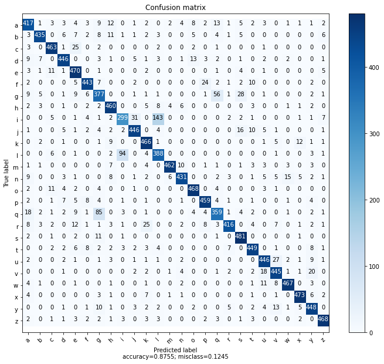

```python
plot_confusion_matrix(a)
```

```python
#пробуем новый оптимайзер
model = nn.Sequential(
    nn.Linear(28 * 28, 200),
    nn.ReLU(),
    nn.Linear(200, 128),
    nn.Linear(128, 26)
)
optimizer = torch.optim.SGD(model.parameters(), lr=0.001, momentum=0.9)
# create a loss function
criterion = nn.CrossEntropyLoss()
epochs = 5
history = []
```

```python
for i in range(epochs):
    for x_batch, y_batch in train_loader:
        x_batch = x_batch.view(x_batch.shape[0], -1)
        y_batch = y_batch
        logits = model(x_batch)
        loss = criterion(logits, y_batch)
        history.append(loss.item())


        optimizer.zero_grad()
        loss.backward()

        optimizer.step()

    print(f'{i+1},\t loss: {history[-1]}')
```

```
1,	 loss: 1.3392118215560913
2,	 loss: 1.1207178831100464
3,	 loss: 1.1979038715362549
4,	 loss: 0.982669472694397
5,	 loss: 0.7136206030845642
```

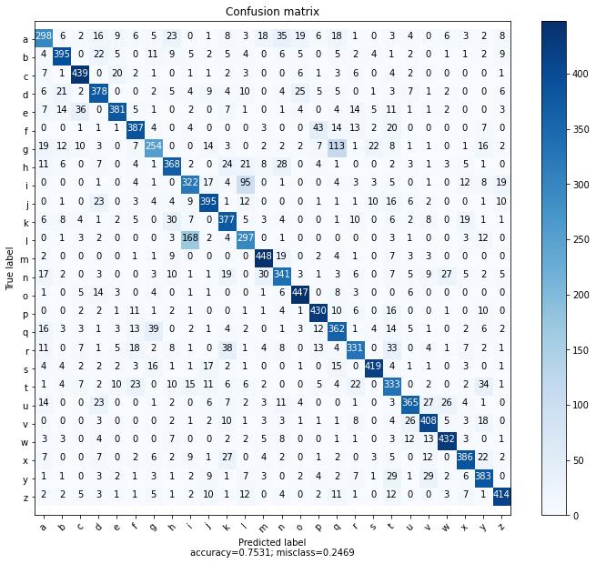

```python
history_x = []
history_y = []
for x_batch, y_batch in test_loader:
    preds = torch.argmax(model(x_batch.view(x_batch.shape[0], -1)), dim=1)
    history_x.append(preds)
    history_y.append(y_batch)
x = []
for i in history_x:
    for j in range(len(i)):
        x.append(int(i[j]))
y = []
for i in history_y:
    for j in range(len(i)):
        y.append(int(i[j]))
a = metrics.confusion_matrix(y_true = y,y_pred =  x)
plot_confusion_matrix(a)
```

```python
batch_size = 32
train_loader = DataLoader(train_dataset, batch_size=batch_size, shuffle=True)
test_loader = DataLoader(test_dataset, batch_size=batch_size, shuffle=True)
```

```python
model = nn.Sequential(
    nn.Linear(28 * 28, 200),
    nn.ReLU(),
    nn.Linear(200, 128),
    nn.Linear(128, 26)
)
optimizer = torch.optim.SGD(model.parameters(), lr=0.001, momentum=0.9)
# create a loss function
criterion = nn.CrossEntropyLoss()
epochs = 5
history = []
```

```python
for i in range(epochs):
    for x_batch, y_batch in train_loader:
        x_batch = x_batch.view(x_batch.shape[0], -1)
        y_batch = y_batch
        logits = model(x_batch)
        loss = criterion(logits, y_batch)
        history.append(loss.item())


        optimizer.zero_grad()
        loss.backward()

        optimizer.step()

    print(f'{i+1},\t loss: {history[-1]}')
```

```
1,	 loss: 0.7844302654266357
2,	 loss: 0.3803606331348419
3,	 loss: 0.09222826361656189
4,	 loss: 0.08283500373363495
5,	 loss: 0.7418832778930664
```

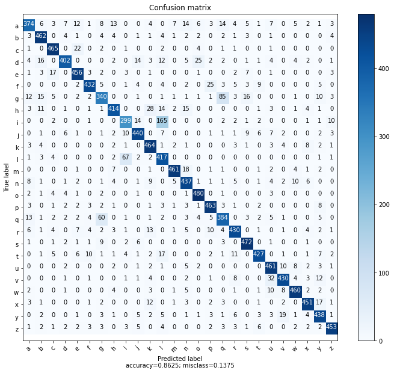

```python
history_x = []
history_y = []
for x_batch, y_batch in test_loader:
    preds = torch.argmax(model(x_batch.view(x_batch.shape[0], -1)), dim=1)
    history_x.append(preds)
    history_y.append(y_batch)
x = []
for i in history_x:
    for j in range(len(i)):
        x.append(int(i[j]))
y = []
for i in history_y:
    for j in range(len(i)):
        y.append(int(i[j]))
a = metrics.confusion_matrix(y_true = y,y_pred =  x)
plot_confusion_matrix(a)
```

Наибольшую точность выдает самая первая модель

**Теперь поработаем с сетями с тремя полносвязными слоями**

```python
model = nn.Sequential(
    nn.Linear(28 * 28, 28*14),
    nn.ReLU(),
    nn.Linear(28*14, 128),
    nn.Linear(128, 64),
    nn.Linear( 64,26)
)
criterion = nn.CrossEntropyLoss()
optimizer = torch.optim.Adam(model.parameters(), lr=1e-3, betas=(0.9, 0.99))
epochs = 5
history = []
```

```python
batch_size = 32
train_loader = DataLoader(train_dataset, batch_size=batch_size, shuffle=True)
test_loader = DataLoader(test_dataset, batch_size=batch_size, shuffle=True)
```

```python
for i in range(epochs):
    for x_batch, y_batch in train_loader:
        x_batch = x_batch.view(x_batch.shape[0], -1)
        y_batch = y_batch
        logits = model(x_batch)
        loss = criterion(logits, y_batch)
        history.append(loss.item())


        optimizer.zero_grad()
        loss.backward()

        optimizer.step()

    print(f'{i+1},\t loss: {history[-1]}')
```

```
1,	 loss: 0.38332128524780273
2,	 loss: 0.48819154500961304
3,	 loss: 0.12551656365394592
4,	 loss: 0.32156527042388916
5,	 loss: 0.03338943049311638
```

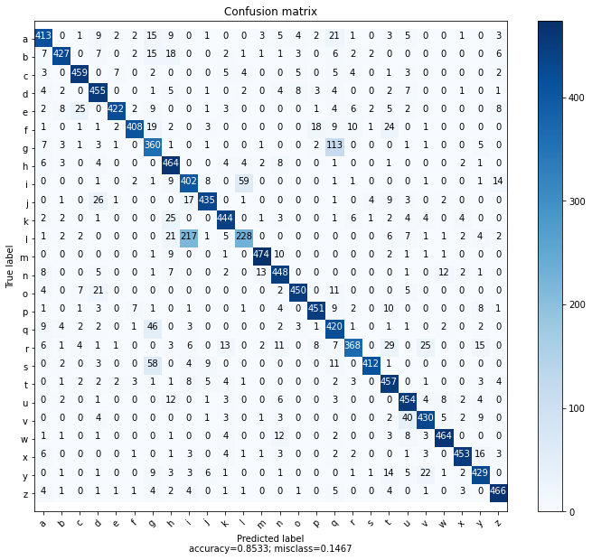

```python
history_x = []
history_y = []
for x_batch, y_batch in test_loader:
    preds = torch.argmax(model(x_batch.view(x_batch.shape[0], -1)), dim=1)
    history_x.append(preds)
    history_y.append(y_batch)
x = []
for i in history_x:
    for j in range(len(i)):
        x.append(int(i[j]))
y = []
for i in history_y:
    for j in range(len(i)):
        y.append(int(i[j]))
a = metrics.confusion_matrix(y_true = y,y_pred =  x)
plot_confusion_matrix(a)
```

```python
model = nn.Sequential(
    nn.Linear(28 * 28, 28*14),
    nn.ReLU(),
    nn.Linear(28*14, 128),
    nn.Linear(128, 64),
    nn.Linear( 64,26)
)
optimizer = torch.optim.SGD(model.parameters(), lr=0.001, momentum=0.9)
# create a loss function
criterion = nn.CrossEntropyLoss()
epochs = 5
history = []
```

```python
for i in range(epochs):
    for x_batch, y_batch in train_loader:
        x_batch = x_batch.view(x_batch.shape[0], -1)
        y_batch = y_batch
        logits = model(x_batch)
        loss = criterion(logits, y_batch)
        history.append(loss.item())


        optimizer.zero_grad()
        loss.backward()

        optimizer.step()

    print(f'{i+1},\t loss: {history[-1]}')
```

```
1,	 loss: 0.7628207206726074
2,	 loss: 0.7684961557388306
3,	 loss: 0.6631001234054565
4,	 loss: 0.16597601771354675
5,	 loss: 0.570223867893219
```

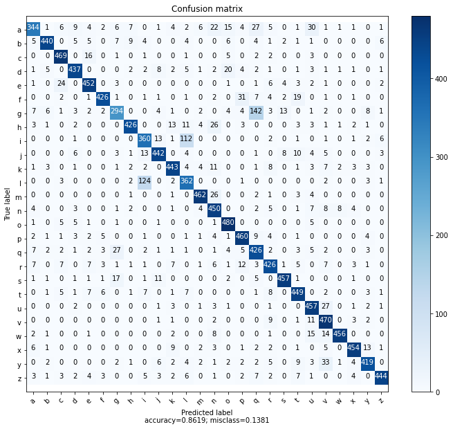

```python
history_x = []
history_y = []
for x_batch, y_batch in test_loader:
    preds = torch.argmax(model(x_batch.view(x_batch.shape[0], -1)), dim=1)
    history_x.append(preds)
    history_y.append(y_batch)
x = []
for i in history_x:
    for j in range(len(i)):
        x.append(int(i[j]))
y = []
for i in history_y:
    for j in range(len(i)):
        y.append(int(i[j]))
a = metrics.confusion_matrix(y_true = y,y_pred =  x)
plot_confusion_matrix(a)
```

Пробуя разные параметры, удается повысить точность незначительно, но до 90% добраться не удается

Перейдем к следующим задачам (выбрал самую эффективную модель из созданных):

```python
batch_size = 128
train_loader = DataLoader(train_dataset, batch_size=batch_size, shuffle=True)
test_loader = DataLoader(test_dataset, batch_size=batch_size, shuffle=True)
```

```python
x_batch, y_batch = next(iter(train_loader))
print('Batch - {}. The answers - {}'.format(x_batch.shape, y_batch.shape))
```

```
Batch - torch.Size([128, 1, 28, 28]). The answers - torch.Size([128])
```

```python
model = nn.Sequential(
  nn.Linear(features, int(features/2)),
  nn.ReLU(),
  nn.Linear(int(features/2), 128),
  nn.Linear(128, 64),
  nn.Linear(64, classes)
)
criterion = nn.CrossEntropyLoss()
optimizer = torch.optim.Adam(model.parameters(), lr=1e-3, betas=(0.9, 0.99))
epochs = 5
history = []
```

```python
%%time
for i in range(epochs):
    for x_batch, y_batch in train_loader:
        x_batch = x_batch.view(x_batch.shape[0], -1)
        y_batch = y_batch
        logits = model(x_batch)
        loss = criterion(logits, y_batch)
        history.append(loss.item())


        optimizer.zero_grad()
        loss.backward()

        optimizer.step()

    print(f'{i+1},\t loss: {history[-1]}')
```

```
1,	 loss: 0.5379992723464966
2,	 loss: 0.4931170344352722
3,	 loss: 0.5025272369384766
4,	 loss: 0.3193606734275818
5,	 loss: 0.4357510805130005
CPU times: user 3min 19s, sys: 9.73 s, total: 3min 29s
Wall time: 3min 29s
```

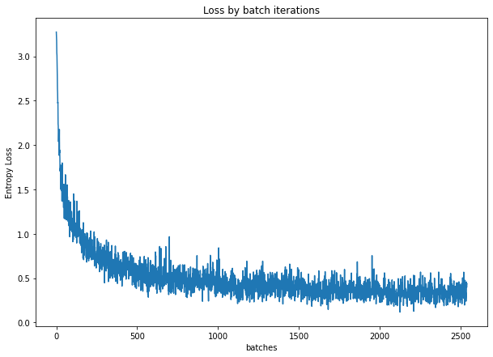

```python
plt.figure(figsize=(10, 7))
plt.plot(history)
plt.title('Loss by batch iterations')
plt.ylabel('Entropy Loss')
plt.xlabel('batches')

plt.show()
```

Несмотря на очень большие колебания, ошибка идет на спад - модель обучается

```python
%%time
history_x = []
history_y = []
for x_batch, y_batch in test_loader:
    preds = torch.argmax(model(x_batch.view(x_batch.shape[0], -1)), dim=1)
    history_x.append(preds)
    history_y.append(y_batch)
x = []
for i in history_x:
    for j in range(len(i)):
        x.append(int(i[j]))
y = []
for i in history_y:
    for j in range(len(i)):
        y.append(int(i[j]))
a = metrics.confusion_matrix(y_true = y,y_pred =  x)
np.trace(a) / float(np.sum(a))
```

```
CPU times: user 7.51 s, sys: 375 ms, total: 7.89 s
Wall time: 7.87 s
```

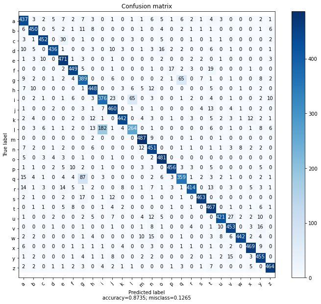

```python
plot_confusion_matrix(a)
```

```python
class_correct = list(0. for i in range(26))
class_total = list(0. for i in range(26))
classes = tuple(str(i) for i in range(26))
pics = None
letters = []
with torch.no_grad():
    for data in test_loader:
        images, labels = data
        predicted = torch.argmax(model(images.view(images.shape[0], -1)), dim=1)
        if predicted[0] != labels[0]:
            pics = images[0]
            letters.append(predicted[0])
            letters.append(labels[0])

        c = (predicted.detach() == labels)
        for i in range(len(labels)):
            label = labels[i]
            class_correct[label] += c[i].item()
            class_total[label] += 1
target_names = 'a b c d e f g h i j k l m n o p q r s t u v w x y z'.split()
loscl = [class_correct[i] / class_total[i] for i in range(26)].sort()
for i in range(26):
    print(f'Accuracy of {target_names[i]}: {100 * class_correct[i] / class_total[i]}%')
print(f'Total accuracy: {sum(class_correct)/ sum(class_total)}')
```

```
Accuracy of a: 87.4%
Accuracy of b: 90.0%
Accuracy of c: 90.4%
Accuracy of d: 87.2%
Accuracy of e: 94.2%
Accuracy of f: 89.8%
Accuracy of g: 77.8%
Accuracy of h: 89.6%
Accuracy of i: 75.2%
Accuracy of j: 92.0%
Accuracy of k: 88.4%
Accuracy of l: 52.8%
Accuracy of m: 97.4%
Accuracy of n: 90.2%
Accuracy of o: 96.2%
Accuracy of p: 91.2%
Accuracy of q: 71.8%
Accuracy of r: 82.8%
Accuracy of s: 92.6%
Accuracy of t: 93.4%
Accuracy of u: 84.2%
Accuracy of v: 90.6%
Accuracy of w: 88.4%
Accuracy of x: 93.8%
Accuracy of y: 91.0%
Accuracy of z: 92.8%
Total accuracy: 0.8735384615384615
```

Вероятность правильно распознать первую букву моей фамилии (букву B) - 90%, чаще всего модель путает её с G

```python
losclsort = sorted([class_correct[i] / class_total[i] for i in range(26)])
loscl = [class_correct[i] / class_total[i] for i in range(26)]
for i in losclsort[:10]:
    k = loscl.index(i)
    print('{}'.format(target_names[k]))
```

```
l
q
i
g
r
u
d
a
k
k
```

```python
target_names = 'a b c d e f g h i j k l m n o p q r s t u v w x y z'.split()

print(f'predicted: {target_names[kek1[0].numpy()]}\nanswer: {target_names[kek1[1].numpy()]}')
```

[output not shown]

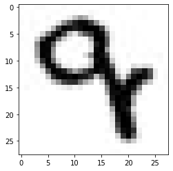

```python
plt.imshow(np.transpose(pics[0]), cmap='Greys')
```

Вывод:

1. Чаще всего путают буквы l, q, i, g, r, u, d, a, k
2. Получилась модель с точностью 87,35%
3. Чаще всего путаются следующие пары букв: g и q, i и l, с и e

### Задание 2

*Вес в общей оценке - 0.35*

1. Постройте и обучите модели нейронной сети с 1-м, 2-мя и 3-мя сверточными слоями.  
   Попробуйте различные значения параметров сверток и числа фильтров на каждом слое. Оцените качество моделей с различными параметрами, проведите сравнительный анализ.
2. Для наилучшей конфигурации из предыдущего пункта, сравните, как меняется качество модели при увеличении размера батча при использовании BatchNorm и GroupNorm.

```python
import torch.nn.functional as F
```

```python
data_tfs = tfs.Compose([
    transforms.ToTensor(),
    transforms.RandomAffine((90, 90)),
    transforms.RandomHorizontalFlip(p=1),
    transforms.Normalize([0.485, 0.456, 0.406], [0.229, 0.224, 0.225]),
    transforms.Grayscale(1)
    ])
```

```python
batch_size = 15
train_loader = DataLoader(train_dataset, batch_size=batch_size, shuffle=True)
test_loader = DataLoader(test_dataset, batch_size=batch_size, shuffle=True)
```

```python
class SimpleConvNet(nn.Module): # 1 сверточный слой

    def __init__(self):
        # вызов конструктора предка
        super(SimpleConvNet, self).__init__()
        self.conv1 = nn.Conv2d(in_channels=1, out_channels=6, kernel_size=3)
        self.pool = nn.MaxPool2d(kernel_size=2, stride=2)
        self.fc1 = nn.Linear(6 * 13 * 13, 2*13*13)
        self.fc2 = nn.Linear(2*13*13, 13*13)
        self.fc3 = nn.Linear(13*13, 78)
        self.fc4 = nn.Linear(78, 26)

    def forward(self, x):
        x = self.pool(F.relu(self.conv1(x)))
        x = x.view(-1, 6 * 13 * 13)  # !!!
        x = F.relu(self.fc1(x))
        x = F.relu(self.fc2(x))
        x = F.relu(self.fc3(x))
        x = self.fc4(x)
        return x


batch = []
net = SimpleConvNet()

batch = next(iter(train_loader))


# выбираем функцию потерь
loss_fn = torch.nn.CrossEntropyLoss()

# выбираем алгоритм оптимизации и learning_rate
learning_rate = 1e-4
# optimizer = torch.optim.Adam(net.parameters(), lr=learning_rate)
optimizer = torch.optim.SGD(net.parameters(), lr=0.001, momentum=0.9)
losses = []
```

```python
cnt = 0
temp = 0
for i, batch in enumerate(tqdm_notebook(train_loader)):
        # так получаем текущий батч
        X_batch, y_batch = batch
        cnt = i
        if i % 1000 == 999:
          temp += 1
```

```
[1,   300] loss: 3.240
[1,   600] loss: 3.084
[1,   900] loss: 2.218
[1,  1200] loss: 1.560
[1,  1500] loss: 1.358
[1,  1800] loss: 1.167
[1,  2100] loss: 1.012
[1,  2400] loss: 0.937
[1,  2700] loss: 0.782
[1,  3000] loss: 0.737
[1,  3300] loss: 0.679
[1,  3600] loss: 0.620
[1,  3900] loss: 0.565
[1,  4200] loss: 0.562
```

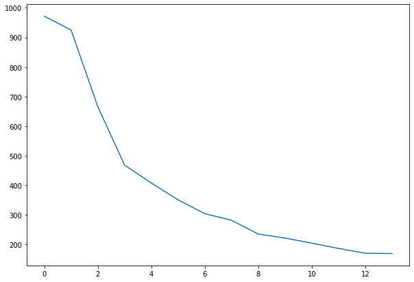

```
[2,   300] loss: 0.491
[2,   600] loss: 0.479
[2,   900] loss: 0.458
[2,  1200] loss: 0.466
[2,  1500] loss: 0.440
[2,  1800] loss: 0.432
[2,  2100] loss: 0.417
[2,  2400] loss: 0.413
[2,  2700] loss: 0.428
[2,  3000] loss: 0.403
[2,  3300] loss: 0.380
[2,  3600] loss: 0.375
[2,  3900] loss: 0.384
[2,  4200] loss: 0.352
```

```
[3,   300] loss: 0.328
[3,   600] loss: 0.338
[3,   900] loss: 0.312
[3,  1200] loss: 0.313
[3,  1500] loss: 0.297
[3,  1800] loss: 0.325
[3,  2100] loss: 0.331
[3,  2400] loss: 0.310
[3,  2700] loss: 0.302
[3,  3000] loss: 0.335
[3,  3300] loss: 0.315
[3,  3600] loss: 0.292
[3,  3900] loss: 0.298
[3,  4200] loss: 0.290
```

```
[4,   300] loss: 0.268
[4,   600] loss: 0.259
[4,   900] loss: 0.257
[4,  1200] loss: 0.256
[4,  1500] loss: 0.242
[4,  1800] loss: 0.264
[4,  2100] loss: 0.258
[4,  2400] loss: 0.249
[4,  2700] loss: 0.268
[4,  3000] loss: 0.266
[4,  3300] loss: 0.258
[4,  3600] loss: 0.240
[4,  3900] loss: 0.257
[4,  4200] loss: 0.253
```

```
[5,   300] loss: 0.210
[5,   600] loss: 0.208
[5,   900] loss: 0.212
[5,  1200] loss: 0.212
[5,  1500] loss: 0.234
[5,  1800] loss: 0.224
[5,  2100] loss: 0.234
[5,  2400] loss: 0.223
[5,  2700] loss: 0.223
[5,  3000] loss: 0.221
[5,  3300] loss: 0.211
[5,  3600] loss: 0.217
[5,  3900] loss: 0.218
[5,  4200] loss: 0.251
```

```
[6,   300] loss: 0.183
[6,   600] loss: 0.176
[6,   900] loss: 0.202
[6,  1200] loss: 0.190
[6,  1500] loss: 0.206
[6,  1800] loss: 0.191
[6,  2100] loss: 0.189
[6,  2400] loss: 0.204
[6,  2700] loss: 0.185
[6,  3000] loss: 0.193
[6,  3300] loss: 0.193
[6,  3600] loss: 0.197
[6,  3900] loss: 0.200
[6,  4200] loss: 0.197
```

```
[7,   300] loss: 0.171
[7,   600] loss: 0.148
[7,   900] loss: 0.182
[7,  1200] loss: 0.171
[7,  1500] loss: 0.182
[7,  1800] loss: 0.182
[7,  2100] loss: 0.164
[7,  2400] loss: 0.147
[7,  2700] loss: 0.165
[7,  3000] loss: 0.175
[7,  3300] loss: 0.178
[7,  3600] loss: 0.178
[7,  3900] loss: 0.185
[7,  4200] loss: 0.177
```

```
[8,   300] loss: 0.143
[8,   600] loss: 0.134
[8,   900] loss: 0.158
[8,  1200] loss: 0.141
[8,  1500] loss: 0.154
[8,  1800] loss: 0.148
[8,  2100] loss: 0.146
[8,  2400] loss: 0.160
[8,  2700] loss: 0.156
[8,  3000] loss: 0.157
[8,  3300] loss: 0.158
[8,  3600] loss: 0.166
[8,  3900] loss: 0.171
[8,  4200] loss: 0.163
```

```
[9,   300] loss: 0.116
[9,   600] loss: 0.122
[9,   900] loss: 0.136
[9,  1200] loss: 0.136
[9,  1500] loss: 0.130
[9,  1800] loss: 0.148
[9,  2100] loss: 0.141
[9,  2400] loss: 0.140
[9,  2700] loss: 0.142
[9,  3000] loss: 0.140
[9,  3300] loss: 0.140
[9,  3600] loss: 0.140
[9,  3900] loss: 0.137
[9,  4200] loss: 0.150
```

```
[10,   300] loss: 0.121
[10,   600] loss: 0.114
[10,   900] loss: 0.124
[10,  1200] loss: 0.123
[10,  1500] loss: 0.127
[10,  1800] loss: 0.113
[10,  2100] loss: 0.129
[10,  2400] loss: 0.111
[10,  2700] loss: 0.143
[10,  3000] loss: 0.127
[10,  3300] loss: 0.135
[10,  3600] loss: 0.131
[10,  3900] loss: 0.127
[10,  4200] loss: 0.144
```

```
[11,   300] loss: 0.109
[11,   600] loss: 0.097
[11,   900] loss: 0.106
[11,  1200] loss: 0.105
[11,  1500] loss: 0.120
[11,  1800] loss: 0.110
[11,  2100] loss: 0.101
[11,  2400] loss: 0.131
[11,  2700] loss: 0.114
[11,  3000] loss: 0.120
[11,  3300] loss: 0.113
[11,  3600] loss: 0.128
[11,  3900] loss: 0.125
[11,  4200] loss: 0.123
```

```
[12,   300] loss: 0.101
[12,   600] loss: 0.090
[12,   900] loss: 0.091
[12,  1200] loss: 0.107
[12,  1500] loss: 0.095
[12,  1800] loss: 0.111
[12,  2100] loss: 0.101
[12,  2400] loss: 0.095
[12,  2700] loss: 0.114
[12,  3000] loss: 0.121
[12,  3300] loss: 0.108
[12,  3600] loss: 0.104
[12,  3900] loss: 0.107
[12,  4200] loss: 0.109
Обучение закончено
```

```python
fig = plt.figure(figsize=(10,7))
ax = fig.add_subplot(1, 1, 1)

for epoch in tqdm_notebook(range(12)):

    running_loss = 0.0
    for i, batch in enumerate(tqdm_notebook(train_loader)):
        X_batch, y_batch = batch

        optimizer.zero_grad()

        y_pred = net(X_batch)
        loss = loss_fn(y_pred, y_batch)
        loss.backward()




        optimizer.step()

        running_loss += loss.item()

        if i % 300 == 299:
            print('[%d, %5d] loss: %.3f' %
                  (epoch + 1, i + 1, running_loss / 300))
            losses.append(running_loss)
            running_loss = 0.0


    ax.clear()
    ax.plot(np.arange(len(losses)), losses)
    plt.show()


print('Обучение закончено')
```

```python
class_correct = list(0. for i in range(26))
y_truem = []
y_predm = []
class_total = list(0. for i in range(26))
classes = tuple(str(i) for i in range(26))
with torch.no_grad():
    for data in test_loader:
        images, labels = data
        y_pred = net(images)
        y_truem.append(labels)
        y_predm.append(y_pred)
        _, predicted = torch.max(y_pred, 1)

        c = (predicted.detach() == labels)
        for i in range(len(labels)):
            label = labels[i]
            class_correct[label] += c[i].item()
            class_total[label] += 1


for i in range(26):
    print(f'Accuracy of {classes[i]} : {100 * class_correct[i] / class_total[i]}%')
print(f'общая accuracy: {sum(class_correct)/ sum(class_total)}')
```

[output not shown]

```python
data_tfs = tfs.Compose([
    transforms.ToTensor(),
    transforms.RandomAffine((90, 90)),
    transforms.RandomHorizontalFlip(p=1),
    transforms.Normalize([0.485, 0.456, 0.406], [0.229, 0.224, 0.225]),
    transforms.Grayscale(1)
    ])

batch_size = 32
train_loader = DataLoader(train_dataset, batch_size=batch_size, shuffle=True)
test_loader = DataLoader(test_dataset, batch_size=batch_size, shuffle=True)
```

```python
  class SimpleConvNet(nn.Module):  # 2 сверточных слоя плюс бач норм
      def __init__(self):
          # вызов конструктора предка
          super(SimpleConvNet, self).__init__()
          self.conv1 = nn.Conv2d(in_channels=1, out_channels=6, kernel_size=3)
          self.bn1 = nn.BatchNorm2d(6)
          self.pool = nn.MaxPool2d(kernel_size=2, stride=2)
          self.conv2 = nn.Conv2d(in_channels=6, out_channels=16, kernel_size=3)
          self.bn2 = nn.BatchNorm2d(16)
          self.fc1 = nn.Linear(5 * 5 * 16, 4*5*5)
          self.fc2 = nn.Linear(4*5*5, 52)
          self.fc3 = nn.Linear(52, 26)

      def forward(self, x):
          x = self.pool(F.relu(self.conv1(x)))
          x = self.pool(F.relu(self.conv2(x)))
  #         print(x.shape)
          x = x.view(-1, 5 * 5 * 16)
          x = F.relu(self.fc1(x))
          x = F.relu(self.fc2(x))
          x = self.fc3(x)
          return x


  batch = []
  net = SimpleConvNet()

  batch = next(iter(train_loader))


  # выбираем функцию потерь
  loss_fn = torch.nn.CrossEntropyLoss()

  # выбираем алгоритм оптимизации и learning_rate
  learning_rate = 1e-4
  # optimizer = torch.optim.Adam(net.parameters(), lr=learning_rate)
  optimizer = torch.optim.SGD(net.parameters(), lr=0.001, momentum=0.9)
  losses = []
```

```python
cnt = 0
temp = 0
for i, batch in enumerate(tqdm_notebook(train_loader)):
        # так получаем текущий батч
        X_batch, y_batch = batch
        cnt = i
        if i % 1000 == 999:
          temp += 1
cnt,temp
```

```
(2031, 2)
```

```
[1,   300] loss: 3.222
[1,   600] loss: 2.733
[1,   900] loss: 1.647
[1,  1200] loss: 1.285
[1,  1500] loss: 1.076
[1,  1800] loss: 0.928
```

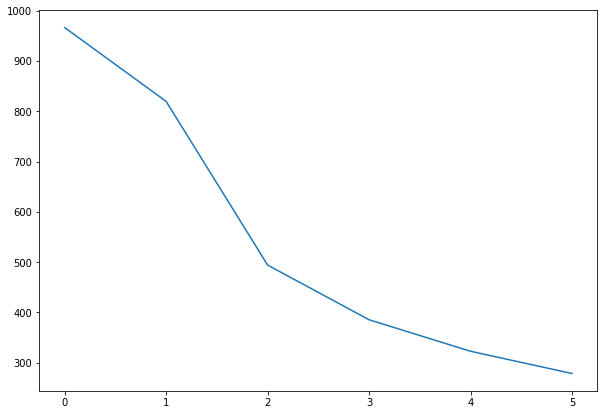

```
[2,   300] loss: 0.723
[2,   600] loss: 0.684
[2,   900] loss: 0.627
[2,  1200] loss: 0.587
[2,  1500] loss: 0.557
[2,  1800] loss: 0.503
```

```
[3,   300] loss: 0.454
[3,   600] loss: 0.439
[3,   900] loss: 0.440
[3,  1200] loss: 0.408
[3,  1500] loss: 0.431
[3,  1800] loss: 0.391
```

```
[4,   300] loss: 0.365
[4,   600] loss: 0.368
[4,   900] loss: 0.353
[4,  1200] loss: 0.357
[4,  1500] loss: 0.332
[4,  1800] loss: 0.325
```

```
[5,   300] loss: 0.316
[5,   600] loss: 0.288
[5,   900] loss: 0.311
[5,  1200] loss: 0.321
[5,  1500] loss: 0.295
[5,  1800] loss: 0.280
Обучение закончено
```

```python
fig = plt.figure(figsize=(10,7))
ax = fig.add_subplot(1, 1, 1)

for epoch in tqdm_notebook(range(5)):

    running_loss = 0.0
    for i, batch in enumerate(tqdm_notebook(train_loader)):
        X_batch, y_batch = batch

        optimizer.zero_grad()

        y_pred = net(X_batch)
        loss = loss_fn(y_pred, y_batch)
        loss.backward()




        optimizer.step()

        running_loss += loss.item()

        if i % 300 == 299:
            print('[%d, %5d] loss: %.3f' %
                  (epoch + 1, i + 1, running_loss / 300))
            losses.append(running_loss)
            running_loss = 0.0


    ax.clear()
    ax.plot(np.arange(len(losses)), losses)
    plt.show()


print('Обучение закончено')
```

```python
class_correct = list(0. for i in range(26))
y_truem = []
y_predm = []
class_total = list(0. for i in range(26))
classes = tuple(str(i) for i in range(26))
with torch.no_grad():
    for data in test_loader:
        images, labels = data
        y_pred = net(images)
        y_truem.append(labels)
        y_predm.append(y_pred)
        _, predicted = torch.max(y_pred, 1)

        c = (predicted.detach() == labels)
        for i in range(len(labels)):
            label = labels[i]
            class_correct[label] += c[i].item()
            class_total[label] += 1


for i in range(26):
    print(f'Accuracy of {classes[i]} : {100 * class_correct[i] / class_total[i]}%')
print(f'общая accuracy: {sum(class_correct)/ sum(class_total)}')
```

[output not shown]

Попробуем улучшить результаты

```python
data_tfs = tfs.Compose([
    transforms.ToTensor(),
    transforms.RandomAffine((90, 90)),
    transforms.RandomHorizontalFlip(p=1),
    transforms.Normalize([0.485, 0.456, 0.406], [0.229, 0.224, 0.225]),
    transforms.Grayscale(1)
    ])

batch_size = 6
train_loader = DataLoader(train_dataset, batch_size=batch_size, shuffle=True)
test_loader = DataLoader(test_dataset, batch_size=batch_size, shuffle=True)
```

```python
class SimpleConvNet(nn.Module):
    def __init__(self):
        super(SimpleConvNet, self).__init__()
        self.conv1 = torch.nn.Conv2d(1, 16, kernel_size=4)
        self.pool = torch.nn.MaxPool2d(kernel_size=2)
        self.bn1 = torch.nn.GroupNorm(2, 16)
        self.conv2 = torch.nn.Conv2d(16, 32, kernel_size=4)
        self.pool2 = torch.nn.MaxPool2d(kernel_size=2)
        self.bn2 = torch.nn.GroupNorm(2, 32)
        self.fc1 = torch.nn.Linear(512, 200)
        self.fc2 = torch.nn.Linear(200, 100)
        self.fc3 = torch.nn.Linear(100, 26)

    def forward(self, x):
        x = self.pool(F.relu(self.conv1(x)))
        x = self.bn1(x)
        x = self.pool2(F.relu(self.conv2(x)))
        x = self.bn2(x)
        x = x.reshape(x.size(0), -1)
        x = F.relu(self.fc1(x))
        x = F.relu(self.fc2(x))
        x = self.fc3(x)
        return x

batch = []
net = SimpleConvNet()

batch = next(iter(train_loader))


# выбираем функцию потерь
loss_fn = torch.nn.CrossEntropyLoss()

# выбираем алгоритм оптимизации и learning_rate
learning_rate = 1e-4
# optimizer = torch.optim.Adam(net.parameters(), lr=learning_rate)
optimizer = torch.optim.SGD(net.parameters(), lr=0.001, momentum=0.9)
losses = []
```

```python
cnt = 0
temp = 0
for i, batch in enumerate(tqdm_notebook(train_loader)):
        # так получаем текущий батч
        X_batch, y_batch = batch
        cnt = i
        if i % 300 == 299:
          temp += 1
cnt,temp
```

```
(10833, 36)
```

```python
from torch.utils.tensorboard import SummaryWriter
writer = SummaryWriter()
ig = plt.figure(figsize=(10,7))
ax = fig.add_subplot(1, 1, 1)

for epoch in tqdm_notebook(range(4)):

    running_loss = 0.0
    for i, batch in enumerate(tqdm_notebook(train_loader)):
        X_batch, y_batch = batch

        optimizer.zero_grad()

        y_pred = net(X_batch)
        loss = loss_fn(y_pred, y_batch)
        writer.add_scalar("Loss/train", loss, epoch)

        loss.backward()

        optimizer.step()

        running_loss += loss.item()

        if i % 300 == 299:
            print('[%d, %5d] loss: %.3f' %
                  (epoch + 1, i + 1, running_loss / 300))
            losses.append(running_loss)
            running_loss = 0.0

    ax.clear()
    ax.plot(np.arange(len(losses)), losses)
    plt.show()

print('Обучение закончено')
```

```
[1,   300] loss: 0.131
[1,   600] loss: 0.152
[1,   900] loss: 0.126
[1,  1200] loss: 0.132
[1,  1500] loss: 0.112
[1,  1800] loss: 0.152
[1,  2100] loss: 0.127
[1,  2400] loss: 0.144
[1,  2700] loss: 0.161
[1,  3000] loss: 0.158
[1,  3300] loss: 0.157
[1,  3600] loss: 0.125
[1,  3900] loss: 0.166
[1,  4200] loss: 0.121
[1,  4500] loss: 0.159
```

[output cut: 21 more lines]

```
[2,   300] loss: 0.108
[2,   600] loss: 0.114
[2,   900] loss: 0.129
[2,  1200] loss: 0.126
[2,  1500] loss: 0.118
[2,  1800] loss: 0.127
[2,  2100] loss: 0.095
[2,  2400] loss: 0.123
[2,  2700] loss: 0.134
[2,  3000] loss: 0.113
[2,  3300] loss: 0.132
[2,  3600] loss: 0.139
[2,  3900] loss: 0.121
[2,  4200] loss: 0.109
[2,  4500] loss: 0.138
```

[output cut: 21 more lines]

```
[3,   300] loss: 0.097
[3,   600] loss: 0.091
[3,   900] loss: 0.129
[3,  1200] loss: 0.111
[3,  1500] loss: 0.103
[3,  1800] loss: 0.129
[3,  2100] loss: 0.112
[3,  2400] loss: 0.101
[3,  2700] loss: 0.133
[3,  3000] loss: 0.106
[3,  3300] loss: 0.120
[3,  3600] loss: 0.138
[3,  3900] loss: 0.128
[3,  4200] loss: 0.098
[3,  4500] loss: 0.097
```

[output cut: 21 more lines]

```
[4,   300] loss: 0.091
[4,   600] loss: 0.092
[4,   900] loss: 0.094
[4,  1200] loss: 0.104
[4,  1500] loss: 0.117
[4,  1800] loss: 0.088
[4,  2100] loss: 0.091
[4,  2400] loss: 0.106
[4,  2700] loss: 0.079
[4,  3000] loss: 0.097
[4,  3300] loss: 0.087
[4,  3600] loss: 0.111
[4,  3900] loss: 0.091
[4,  4200] loss: 0.105
[4,  4500] loss: 0.115
```

[output cut: 22 more lines]

```python
class_correct = list(0. for i in range(26))
y_truem = []
y_predm = []
class_total = list(0. for i in range(26))
classes = tuple(str(i) for i in range(26))
with torch.no_grad():
    for data in test_loader:
        images, labels = data
        y_pred = net(images)
        y_truem.append(labels)
        y_predm.append(y_pred)
        _, predicted = torch.max(y_pred, 1)

        c = (predicted.detach() == labels)
        for i in range(len(labels)):
            label = labels[i]
            class_correct[label] += c[i].item()
            class_total[label] += 1


for i in range(26):
    print(f'Accuracy of {classes[i]} : {100 * class_correct[i] / class_total[i]}%')
print(f'общая accuracy: {sum(class_correct)/ sum(class_total)}')
```

[output not shown]

### Задание 3

Обучите модель с точностью (accuracy) на тестовых данных:

- `>= 0.85` +1 балл
- `>= 0.95` +2 балла
- `>= 0.99` +3 балла

**смотрите предыдущее задание :)**

## Бонусные задания

**Задание 1 (1 балл).**

Напишите на листке белой бумаги (маркером или ручкой) от 5 разных букв (можно больше 5 букв в целом с повторениями, но должно быть минимум 5 разных) английского алфавита (в датасете есть как прописные, так и строчные буквы). Сфотографируйте букву и приведите её картинку к размеру $28\times28$ и, желательно, к чёрно-белой палитре цветов. Передайте получившиеся изображения вашей модели и выполните предсказание, оцените результат.

**Tips:**

- В датасете все буквы занимают практически всё пространство картинки по высоте или ширине (или вместе). Если ваша буква будет слишком маленькой или большой, это может повлиять на результат детекции.
- Помните, что буква должна быть белого цвета, а фон - чёрного.
- Описание ваших действий при выполнении этого задания (что вы использовали, чтобы привести картинку к нужному виду) категорически приветствуется :)

**Задание 2 (1 балл):**

Используйте transfer learning подход для решения задачи - дообучите какую-либо модель, предобученную на ImageNet, для классификации рукописных букв. Оцените качество решения.  
В качестве предобученой модели можно взять одну из [torchvision models](https://pytorch.org/vision/stable/models.html).

**Задание 3 (1 балл):**

Добавьте вывод значений функции потерь и accuracy в tensorboard.  
Метрики нужно выводить и для обучающей, и для тестовой выборки.